# Marine Ecological Modelling Global Climate Change

Jorge Assis, PhD // Centre of Marine Sciences, University of Algarve

## Model evaluation

## Model evaluation without cross-validation

Model evaluation computed only with the training dataset.

```r
# load a presence dataset of a Mediterranean coral
presences <- read.csv("Data/dataBases/Paramuricea_clavata.csv", sep = ";")
presences <- presences[, c("Lon", "Lat")]

# load layers
tempMin <- raster("Data/rasterLayers/Climate/Present/OceanTemperature Benthic Mean Pred LtMin.tif")
tempMax <- raster("Data/rasterLayers/Climate/Present/OceanTemperature Benthic Mean Pred LtMax.tif")
oxygen <- raster("Data/rasterLayers/Climate/Present/DissolvedMolecularOxygen Benthic Mean Pred Mean.tif")
productivity <- raster("Data/rasterLayers/Climate/Present/TotalPrimaryProductionPhyto Benthic Mean Pred Mean.tif")

# stack and rename layers
envConditionsPresent <- stack(tempMin, tempMax, oxygen, productivity)
names(envConditionsPresent) <- c("tempMin", "tempMax", "oxygen", "productivity")
```

S5 // Predictive performance in Ecological Modelling

```r
# generate pseudo absences
absences <- pseudoAbsences(envConditionsPresent, presences, n = 10000)

# extract environmental values and make a data.frame with PA information
modelData <- prepareModelData(presences, absences, envConditionsPresent)

# fit a BRT model to the dataset
model <- train("BRT", modelData, folds = NULL)

# determine threshold dependent indices (assumes 0.5)
getAccuracy(model)
```

```
##   threshold       tss sensitivity specificity
## 1       0.5 0.8927053   0.8938053      0.9989
```

S5 // Predictive performance in Ecological Modelling

```r
# The effect of threshold in threshold dependent indices Low threshold retrieves high
# sensitivity
getAccuracy(model, threshold = 0.01)
```

```
##   threshold    tss sensitivity specificity
## 1      0.01 0.9847           1      0.9847
```

```r
# High threshold retrieve low sensitivity
getAccuracy(model, threshold = 0.99)
```

```
##   threshold        tss sensitivity specificity
## 1      0.99 0.02654867  0.02654867           1
```

S5 // Predictive performance in Ecological Modelling

```r
# determine the threshold maximizing the sum of sensitivity and specificity
threshold <- thresholdMaxTSS(model)
```

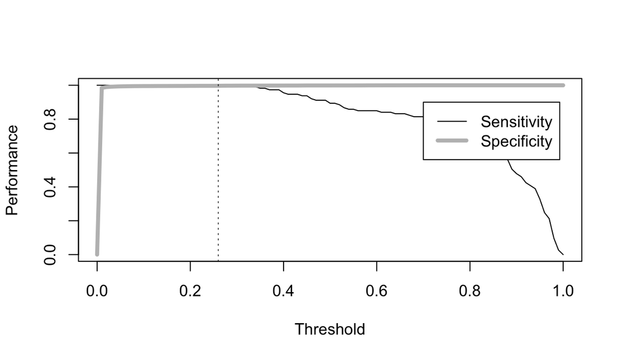

```r
threshold
```

```
## [1] 0.26
```

S5 // Predictive performance in Ecological Modelling

```r
# determine model performance
getAccuracy(model, threshold = threshold)
```

```
##   threshold   tss sensitivity specificity
## 1      0.26 0.997           1       0.997
```

S5 // Predictive performance in Ecological Modelling

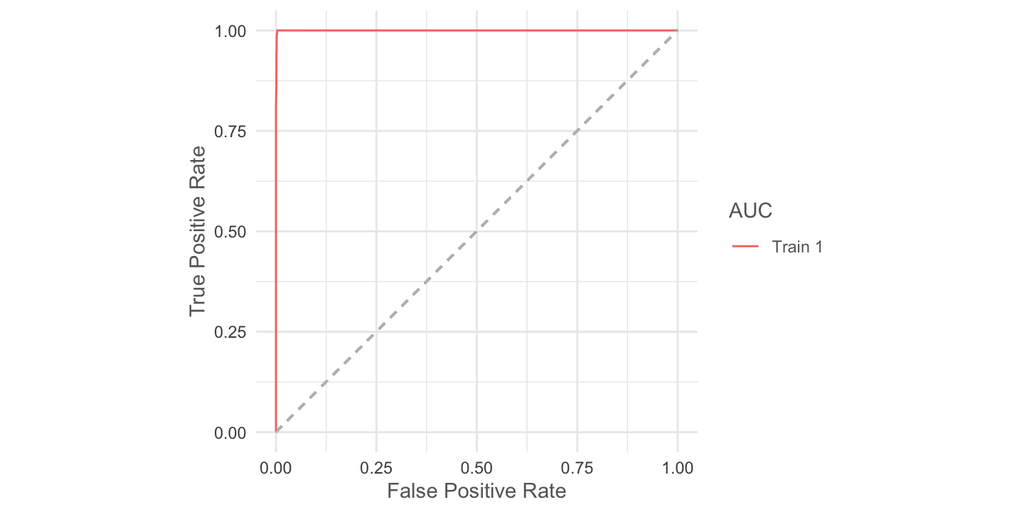

```r
# plot the threshold-independent Receiver operating characteristic
plotROC(model)
```

```r
# determine the threshold-independent AUC
getAUC(model)
```

```
## [1] 0.999785
```

S5 // Predictive performance in Ecological Modelling

### Challenge 5.1

The main objective of this challenge is to **fit** a BRT model and assess its **predictive performance** with AUC without cross-validation.

**Packages, data and functions to accomplish the challenge:**

Go to Menu -> Sessions -> Set the working directory -> My directory of Sessions_[P]  
Run: source(“sourceFunctions.R”)  
Files to use:  
(…)  
Functions to use:  
read.csv(path)  
crop(object)  
pseudoAbsences(object)  
prepareModelData(object)  
train(object)  
plotROC(object)  
getAUC(object)

S5 // Predictive performance in Ecological Modelling

## Model evaluation with cross-validation

Model evaluation computed with a proper test dataset.

```r
# Cross validation with random partitioning of 10 folds
folds <- randomFolds(modelData, k = 10)

# fit a BRT model to the dataset
model <- train("BRT", modelData, folds = folds)

# determine AUC
getAUC(model, test = TRUE)
```

```
## [1] 0.9977216
```

S5 // Predictive performance in Ecological Modelling

```r
# Cross validation with 4 blocks partitioning [getBlocks !]
folds2 <- getBlocks(modelData)

# fit a BRT model to the dataset
model <- train("BRT", modelData, folds = folds2)

# determine AUC
getAUC(model, test = TRUE)
```

```
## [1] 0.9900914
```

S5 // Predictive performance in Ecological Modelling

### Challenge 5.2

The main objective of this challenge is to **fit** a BRT model and assess its **predictive performance** with AUC and cross-validation.

**Packages, data and functions to accomplish the challenge:**

Go to Menu -> Sessions -> Set the working directory -> My directory of Sessions_[P]  
Run: source(“sourceFunctions.R”)  
Files to use:  
(…)  
Functions to use:  
read.csv(path)  
crop(object)  
pseudoAbsences(object)  
prepareModelData(object)  
getBlocks(object)  
train(object)  
plotROC(object)  
getAUC(object)

S5 // Predictive performance in Ecological Modelling

## Variable relative importance and response curves

Inspecting variable relative importance and response curves to assess for ecological meaning in the models.

```r
# calculate the variable relative importance with permutations
viModel <- varImp(model, permut = 5)
viModel
```

```
##       Variable Permutation_importance    sd
## 1      tempMin                 93.200 1.794
## 2 productivity                  3.075 1.717
## 3      tempMax                  2.275 0.538
## 4       oxygen                  1.425 1.595
```

S5 // Predictive performance in Ecological Modelling

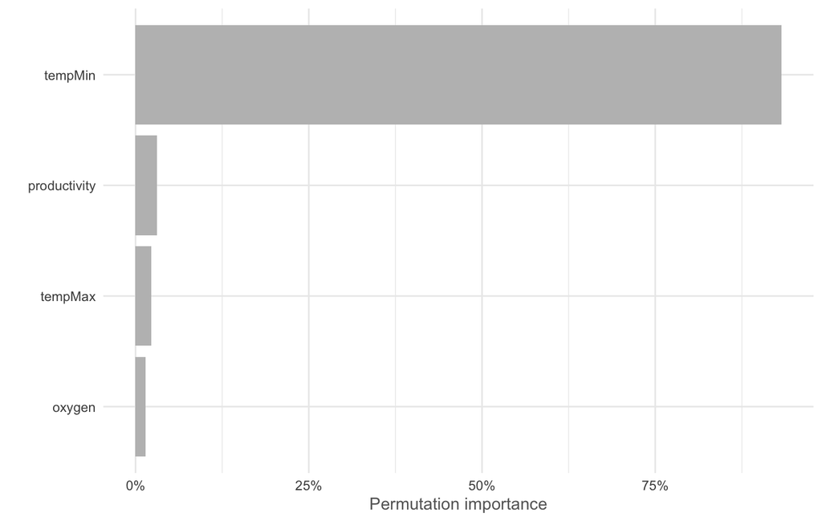

```r
plotVarImp(viModel)
```

S5 // Predictive performance in Ecological Modelling

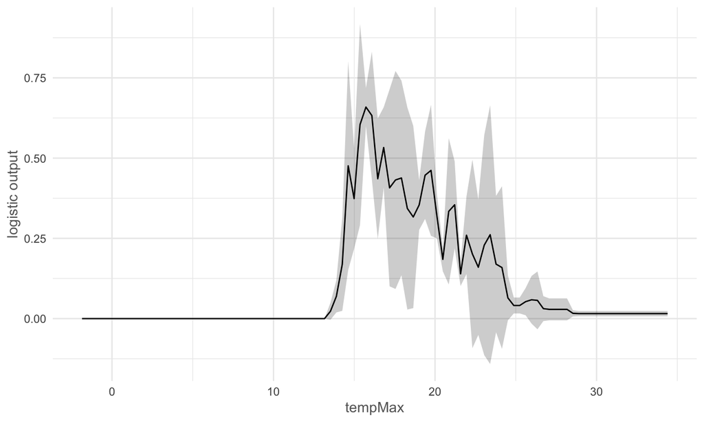

```r
# inspecting response curves
plotResponse(model, var = "tempMax", type = "logistic", color = "Black")
```

S5 // Predictive performance in Ecological Modelling

### Challenge 5.3

The main objective of this challenge is to **evaluate** a model by inspecting variable relative importance and response curves.

**Packages, data and functions to accomplish the challenge:**

Go to Menu -> Sessions -> Set the working directory -> My directory of Sessions_[P]  
Run: source(“sourceFunctions.R”)  
Files to use:  
(…)  
Functions to use:  
read.csv(path)  
crop(object)  
pseudoAbsences(object) & prepareModelData(object)  
get.block(object)  
train(object)  
varImp(object)  
plotVarImp(object)  
plotResponse(object)

S5 // Predictive performance in Ecological Modelling

## References

Global change impacts on biodiversity. Available at: https://damariszurell.github.io/HU-GCIB

Copyright (c) Earth Lab. Available at: https://www.earthdatascience.org.

Open Science for Synthesis: Gulf Research Program Workshop. Available at: https://github.com/NCEAS/oss-lessons

Gimond, M. (2019) Intro to GIS and Spatial Analysis. Available at: https://mgimond.github.io/Spatial/